# My Simple Logistic Regression

## Background

Every year 30 teams in Major League Baseball compete to be able to win the World Series. There’s only one champion, however after the regular season ten different teams of the 30 make it to the playoffs. Each team invest hundreds of millions of dollars to get there. The question posed is how many wins should a team be shooting for in order to make it to the playoffs? Depending on each amount of wins the teams have, what is their probability of making it to the playoffs?

I’ll use the model below to explain my reasoning.
$$P(Y_i = 1|\, x_i) = \frac{e^{\beta_0 + \beta_1 x_i}}{1+e^{\beta_0 + \beta_1 x_i}} = \pi_i$$

I’d like to define the meaning of $i$:

- $Y_i=1$ would mean that the MLB team will make the Playoffs.
- $Y_i=0$ would mean that the MLB team fails to reach the Playoffs.
- $X_i$ will represent the amount of wins each team has at the end of the regular season.

## Data

```r
datatable(mlbwins,options = list(lengthMenu=c(5,10,30,100)))
```

|  | Year | Team | Wins | Playoffs |
| --- | --- | --- | --- | --- |
| 1 | 2017 | BOS | 93 | 1 |
| 2 | 2017 | NYY | 91 | 1 |
| 3 | 2017 | TB | 80 | 0 |
| 4 | 2017 | TOR | 76 | 0 |
| 5 | 2017 | BAL | 75 | 0 |
| 6 | 2017 | CLE | 102 | 1 |
| 7 | 2017 | MIN | 85 | 1 |
| 8 | 2017 | KC | 80 | 0 |
| 9 | 2017 | CWS | 67 | 0 |
| 10 | 2017 | DET | 64 | 0 |

[output cut: 200 more lines]

## Analysis

The plot below helps us understand the Logistic Regression model.

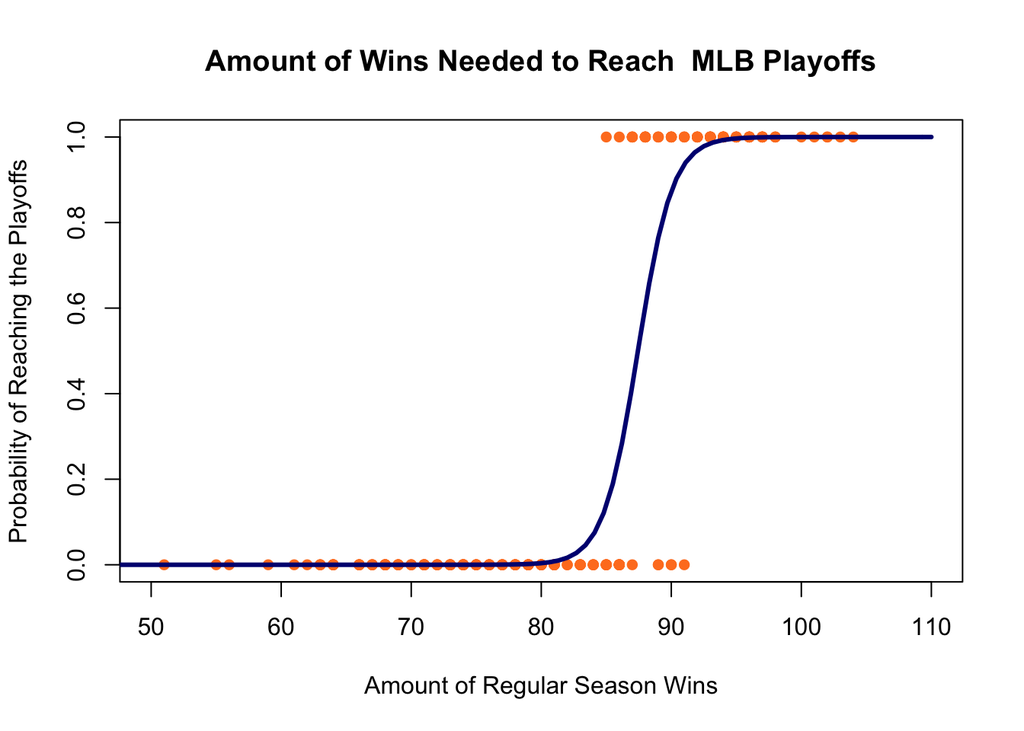

```r
plot(Playoffs>0~Wins, data= mlbwins, xlim=c(50, 110), pch=16, col='chocolate1', xlab='Amount of Regular Season Wins', ylab='Probability of Reaching the Playoffs', main ='Amount of Wins Needed to Reach  MLB Playoffs')
curve(exp(-65.8038+.7526*x)/(1+exp(-65.8038+.7526*x)), from=40, to=110, add=TRUE, col='navy', lwd=3)
```

I’ve summarized the coefficients and the test with the following table. The data shws significant results as the p-value is 9.535e-07. Thus we cand assume that $\beta_1$ is not equal to zero.

```r
mlbglm<-glm(Playoffs>0~Wins, data=mlbwins, family=binomial)
pander(summary(mlbglm))
```

|  | Estimate | Std. Error | z value | Pr(>\|z\|) |
| --- | --- | --- | --- | --- |
| **(Intercept)** | -65.8 | 13.42 | -4.903 | 9.419e-07 |
| **Wins** | 0.7526 | 0.1536 | 4.901 | 9.535e-07 |

(Dispersion parameter for binomial family taken to be 1 )

| Null deviance: | 264.48 on 209 degrees of freedom |
| --- | --- |
| Residual deviance: | 52.33 on 208 degrees of freedom |

Also, it’s important to test the effectiveness of the Logistic Regression test on this data, so I performed a Hosmer-Lemeshow goodness of Fit test.

I received the following results:

```r
pander(hoslem.test(mlbglm$y, mlbglm$fitted.values))
```

Hosmer and Lemeshow goodness of fit (GOF) test: `mlbglm$y, mlbglm$fitted.values`

| Test statistic | df | P value |
| --- | --- | --- |
| 4.783 | 8 | 0.7805 |

As seen in this test, the p-value is .7805. This will condlude that our null hypothesis that the logistic regression model is appropriate for this data is true. Therefore, our results are meaningful.